# Case Study

## Titanic: Machine Learning From Disaster

### Description

The sinking of the RMS Titanic is one of the most infamous shipwrecks in history. On April 15, 1912, during her maiden voyage, the Titanic sank after colliding with an iceberg, killing 1502 out of 2224 passengers and crew. This sensational tragedy shocked the international community and led to better safety regulations for ships.

One of the reasons that the shipwreck led to such loss of life was that there were not enough lifeboats for the passengers and crew. Although there was some element of luck involved in surviving the sinking, some groups of people were more likely to survive than others, such as women, children, and the upper-class.

In this challenge, we ask you to complete the analysis of what sorts of people were likely to survive. In particular, we ask you to apply the tools of machine learning to predict which passengers survived the tragedy.

### Overview

The data has been provided as a single training file:

- training set (train.csv)

The **training set** should be used to build your machine learning models. For the training set, we provide the outcome (also known as the “ground truth”) for each passenger. Your model will be based on “features” like passengers’ gender and class.

### **Key**

PassengerId

Unique Identifier of each passenger

Survived

Survival

0 = No, 1 = Yes

Pclass

Ticket class

1 = 1st, 2 = 2nd, 3 = 3rd

Name

Name of Passenger

Sex

Gender

Age

Age in years

SibSp

# of siblings / spouses aboard the Titanic

Parch

# of parents / children aboard the Titanic

Ticket

Ticket number

Fare

Passenger fare

Cabin

Cabin number

Embarked

Port of Embarkation

C = Cherbourg, Q = Queenstown, S = Southampton

- Detail of some of the variables is provided. You need to explore rest of the varibles yourself.

#### Import Libraries

```python
%config IPCompleter.greedy=True
import pandas as pd
import matplotlib.pyplot as plt
import numpy as np
from sklearn import datasets
from sklearn import metrics
from sklearn.ensemble import ExtraTreesClassifier
from sklearn.metrics import accuracy_score
from sklearn.model_selection import train_test_split
from sklearn.tree import DecisionTreeClassifier
from sklearn.linear_model import LogisticRegression
```

#### Read Data

```python
df=pd.read_csv("train.csv")
```

#### Dimensions of Data

```python
print(df.shape)
print("num of columns="+ str(df.shape[1]))
print("num of rows="+ str(df.shape[0]))
```

```
(891, 12)
num of columns=12
num of rows=891
```

#### Peak at the Data

```python
df.head(10)
```

|  | PassengerId | Survived | Pclass | Name | Sex | Age | SibSp | Parch | Ticket | Fare | Cabin | Embarked |
| --- | --- | --- | --- | --- | --- | --- | --- | --- | --- | --- | --- | --- |
| 0 | 1 | 0 | 3 | Braund, Mr. Owen Harris | male | 22.0 | 1 | 0 | A/5 21171 | 7.2500 | NaN | S |
| 1 | 2 | 1 | 1 | Cumings, Mrs. John Bradley (Florence Briggs Th... | female | 38.0 | 1 | 0 | PC 17599 | 71.2833 | C85 | C |
| 2 | 3 | 1 | 3 | Heikkinen, Miss. Laina | female | 26.0 | 0 | 0 | STON/O2. 3101282 | 7.9250 | NaN | S |
| 3 | 4 | 1 | 1 | Futrelle, Mrs. Jacques Heath (Lily May Peel) | female | 35.0 | 1 | 0 | 113803 | 53.1000 | C123 | S |
| 4 | 5 | 0 | 3 | Allen, Mr. William Henry | male | 35.0 | 0 | 0 | 373450 | 8.0500 | NaN | S |
| 5 | 6 | 0 | 3 | Moran, Mr. James | male | NaN | 0 | 0 | 330877 | 8.4583 | NaN | Q |
| 6 | 7 | 0 | 1 | McCarthy, Mr. Timothy J | male | 54.0 | 0 | 0 | 17463 | 51.8625 | E46 | S |
| 7 | 8 | 0 | 3 | Palsson, Master. Gosta Leonard | male | 2.0 | 3 | 1 | 349909 | 21.0750 | NaN | S |
| 8 | 9 | 1 | 3 | Johnson, Mrs. Oscar W (Elisabeth Vilhelmina Berg) | female | 27.0 | 0 | 2 | 347742 | 11.1333 | NaN | S |
| 9 | 10 | 1 | 2 | Nasser, Mrs. Nicholas (Adele Achem) | female | 14.0 | 1 | 0 | 237736 | 30.0708 | NaN | C |

```python
df.tail(10)
```

|  | PassengerId | Survived | Pclass | Name | Sex | Age | SibSp | Parch | Ticket | Fare | Cabin | Embarked |
| --- | --- | --- | --- | --- | --- | --- | --- | --- | --- | --- | --- | --- |
| 881 | 882 | 0 | 3 | Markun, Mr. Johann | male | 33.0 | 0 | 0 | 349257 | 7.8958 | NaN | S |
| 882 | 883 | 0 | 3 | Dahlberg, Miss. Gerda Ulrika | female | 22.0 | 0 | 0 | 7552 | 10.5167 | NaN | S |
| 883 | 884 | 0 | 2 | Banfield, Mr. Frederick James | male | 28.0 | 0 | 0 | C.A./SOTON 34068 | 10.5000 | NaN | S |
| 884 | 885 | 0 | 3 | Sutehall, Mr. Henry Jr | male | 25.0 | 0 | 0 | SOTON/OQ 392076 | 7.0500 | NaN | S |
| 885 | 886 | 0 | 3 | Rice, Mrs. William (Margaret Norton) | female | 39.0 | 0 | 5 | 382652 | 29.1250 | NaN | Q |
| 886 | 887 | 0 | 2 | Montvila, Rev. Juozas | male | 27.0 | 0 | 0 | 211536 | 13.0000 | NaN | S |
| 887 | 888 | 1 | 1 | Graham, Miss. Margaret Edith | female | 19.0 | 0 | 0 | 112053 | 30.0000 | B42 | S |
| 888 | 889 | 0 | 3 | Johnston, Miss. Catherine Helen "Carrie" | female | NaN | 1 | 2 | W./C. 6607 | 23.4500 | NaN | S |
| 889 | 890 | 1 | 1 | Behr, Mr. Karl Howell | male | 26.0 | 0 | 0 | 111369 | 30.0000 | C148 | C |
| 890 | 891 | 0 | 3 | Dooley, Mr. Patrick | male | 32.0 | 0 | 0 | 370376 | 7.7500 | NaN | Q |

#### Attributes in Data

```python
df.columns
```

```
Index(['PassengerId', 'Survived', 'Pclass', 'Name', 'Sex', 'Age', 'SibSp',
       'Parch', 'Ticket', 'Fare', 'Cabin', 'Embarked'],
      dtype='object')
```

#### Data types of Attributes

```python
print(df.dtypes)
print()
print("Discrete Variables")
print("Passenger Id, Survived, Pclass, Name, Sex, SibSp, Parch, Ticket, Cabin, Embarked")
print()
print("Continuous Variables")
print("Age, Fare")
```

```
PassengerId      int64
Survived         int64
Pclass           int64
Name            object
Sex             object
Age            float64
SibSp            int64
Parch            int64
Ticket          object
Fare           float64
Cabin           object
Embarked        object
dtype: object

Discrete Variables
Passenger Id, Survived, Pclass, Name, Sex, SibSp, Parch, Ticket, Cabin, Embarked

Continuous Variables
Age, Fare
```

#### Describe the Data

```python
df.describe()

###
### Print the description of data
### You should know what it means to describe a continuous attribute
### And what it means to describe a discrete attribute
### Make separate blocks for each of these
### Write your code here
###
```

|  | PassengerId | Survived | Pclass | Age | SibSp | Parch | Fare |
| --- | --- | --- | --- | --- | --- | --- | --- |
| count | 891.000000 | 891.000000 | 891.000000 | 714.000000 | 891.000000 | 891.000000 | 891.000000 |
| mean | 446.000000 | 0.383838 | 2.308642 | 29.699118 | 0.523008 | 0.381594 | 32.204208 |
| std | 257.353842 | 0.486592 | 0.836071 | 14.526497 | 1.102743 | 0.806057 | 49.693429 |
| min | 1.000000 | 0.000000 | 1.000000 | 0.420000 | 0.000000 | 0.000000 | 0.000000 |
| 25% | 223.500000 | 0.000000 | 2.000000 | 20.125000 | 0.000000 | 0.000000 | 7.910400 |
| 50% | 446.000000 | 0.000000 | 3.000000 | 28.000000 | 0.000000 | 0.000000 | 14.454200 |
| 75% | 668.500000 | 1.000000 | 3.000000 | 38.000000 | 1.000000 | 0.000000 | 31.000000 |
| max | 891.000000 | 1.000000 | 3.000000 | 80.000000 | 8.000000 | 6.000000 | 512.329200 |

```python
survivalPercentage=df.Survived.mean() * 100
print("percentage of passengers survived=" + str(round(survivalPercentage,2)))
```

```
percentage of passengers survived=38.38
```

```python
pclass1= df["Pclass"]==1
pclass2= df["Pclass"]==2
pclass3= df["Pclass"]==3
df.Pclass.isnull().any()

pclass1Percent=pclass1.sum()/len(df)
pclass1Percent*=100
print("Percentage of customers bought 1st class="+str(round(pclass1Percent,2)))

pclass2Percent=pclass2.sum()/len(df)
pclass2Percent*=100
print("Percentage of customers bought 2nd class="+str(round(pclass2Percent,2)))

pclass3Percent=pclass3.sum()/len(df)
pclass3Percent*=100
print("Percentage of customers bought 3rd class="+str(round(pclass3Percent,2)))


pclass1Sur=(df["Pclass"]==1) & (df["Survived"]==1)
pclass2Sur=(df["Pclass"]==2) & (df["Survived"]==1)
pclass3Sur=(df["Pclass"]==3) & (df["Survived"]==1)

pclass1SurPer= pclass1Sur.sum()/pclass1.sum()
pclass2SurPer= pclass2Sur.sum()/pclass2.sum()
pclass3SurPer= pclass3Sur.sum()/pclass3.sum()

print()

print("percentage of pclass1 passengers survived="+ str(round(pclass1SurPer,2)))
print("percentage of pclass2 passengers survived="+ str(round(pclass2SurPer,2)))
print("percentage of pclass3 passengers survived="+ str(round(pclass3SurPer,2)))

print()
#pclass1Sur=pclass1Sur["Survived"]>1
pclassCorr= df['Pclass'].corr(df['Survived'])
print("corelation between passenger class and survival="+ str(round(pclassCorr,2)))
print("means higher the passenger class number the less likely you will survive")
```

```
Percentage of customers bought 1st class=24.24
Percentage of customers bought 2nd class=20.65
Percentage of customers bought 3rd class=55.11

percentage of pclass1 passengers survived=0.63
percentage of pclass2 passengers survived=0.47
percentage of pclass3 passengers survived=0.24

corelation between passenger class and survival=-0.34
means higher the passenger class number the less likely you will survive
```

```python
#malefilter= df['Sex']=="male"
df['Sex'] = df['Sex'].map({'female': 1, 'male': 0})

maleFilter=df['Sex']==0
femaleFilter=df['Sex']==1

print("num of male passengers=" + str(maleFilter.sum()))
print("num of male passengers=" + str(femaleFilter.sum()))



#df['Sex'].corr(df['Survived'])
```

```
num of male passengers=577
num of male passengers=314
```

#### Exploratory Data Analysis

```python
###
### For this section you should plot 2 graphs for each attribute
### First graph should display the distribution of data in each attribute
### Second graph should display how the attribute changes with respect to target class
###
### Take advantage of matplotlib and any other plotting library
### Remember your graph should be meaningful and properly labeled
### You should understand that when the type of variable changes - it's representation also changes
###
### In some of the attributes you would discover that plotting them is not possible
### Could you tell why plotting these attributes is not possible?
### Is there any way to resolve this issue?
###
### Please remember not to make any changes in the original dataframe
###
### Write your code here
###
```

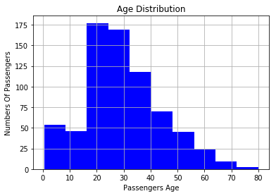

```python
age=df["Age"]
age=age.dropna()
plt.hist(age,10, facecolor='blue')

plt.title('Age Distribution')

plt.xlabel('Passengers Age')
plt.ylabel('Numbers Of Passengers')
plt.grid(True)

plt.show()
```

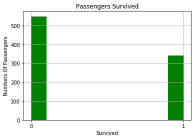

```python
survived=df["Survived"]
survived=survived.dropna()
plt.hist(survived, facecolor='green')

plt.title('Passengers Survived')

plt.xticks(range(0, 2))
plt.xlabel('Survived')
plt.ylabel('Numbers Of Passengers')
plt.grid(True)

plt.grid(True)

plt.show()
```

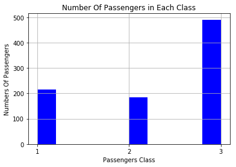

```python
pclassPass = df['Pclass']
plt.xlabel('Passengers Class')
plt.ylabel('Numbers Of Passengers')
plt.grid(True)
plt.title('Number Of Passengers in Each Class')
plt.xticks(range(0, 4))
plt.hist(pclassPass, facecolor='blue');
plt.show()
```

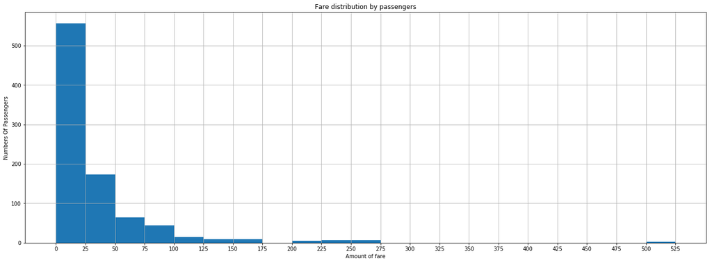

```python
fares=df["Fare"]

fig = plt.figure(figsize=(23,8))
ax = fig.add_subplot(1, 1, 1)

# Major ticks every 20, minor ticks every 5
major_ticks = np.arange(0, 550, 25)


ax.set_xticks(major_ticks)




plt.xlabel('Amount of fare')
plt.ylabel('Numbers Of Passengers')
plt.grid(True)
plt.title('Fare distribution by passengers')



binwidth= int(25)

plt.hist(fares, bins=range( int(min(fares)), int(max(fares)) + binwidth, binwidth))

# plt.hist(fares,bins=[0,50,100,150,200,250,300,350,400,450,500,550], facecolor='blue');

plt.show()
```

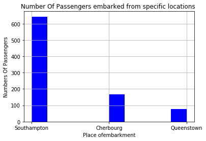

```python
Embarks = df['Embarked'].map({'S': 0, 'C': 1,'Q':2})


Embarks= Embarks.dropna()
plt.xticks(range(0, 3),('Southampton', 'Cherbourg','Queenstown'))

plt.xlabel('Place ofembarkment')
plt.ylabel('Numbers Of Passengers')
plt.grid(True)
plt.title('Number Of Passengers embarked from specific locations ')

plt.hist(Embarks, facecolor='blue');
plt.show()
```

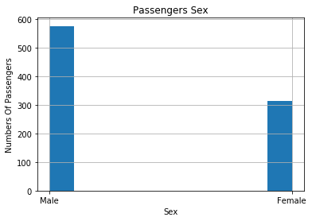

```python
sex = df["Sex"]

plt.hist(sex)
plt.title('Passengers Sex')
plt.xticks(range(0, 2),('Male', 'Female'))
plt.xlabel('Sex')
plt.grid(True);
plt.ylabel('Numbers Of Passengers')
plt.show()
```

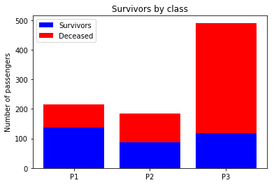

```python
pclass1= df["Pclass"]==1
pclass2= df["Pclass"]==2
pclass3= df["Pclass"]==3

pclass1=pclass1.sum()
pclass2=pclass2.sum()
pclass3=pclass3.sum()



pclass1Sur=(df["Pclass"]==1) & (df["Survived"]==1)
pclass2Sur=(df["Pclass"]==2) & (df["Survived"]==1)
pclass3Sur=(df["Pclass"]==3) & (df["Survived"]==1)


pclass1Sur=pclass1Sur.sum()
pclass2Sur=pclass2Sur.sum()
pclass3Sur=pclass3Sur.sum()

pclass1NotSur=pclass1-pclass1Sur
pclass2NotSur=pclass2-pclass2Sur
pclass3NotSur=pclass3-pclass3Sur


A=[pclass1Sur,pclass2Sur,pclass3Sur]
B=[pclass1NotSur,pclass2NotSur,pclass3NotSur]

X=np.arange(3)

plt.ylabel('Number of passengers')

plt.title('Survivors by class')

plt.xticks(X, ('P1', 'P2', 'P3'))

p1= plt.bar(X, A, color = 'b')
p2=plt.bar(X, B, color = 'r', bottom = A)

plt.legend((p1[0], p2[0]), ('Survivors', 'Deceased'))

plt.show()
```

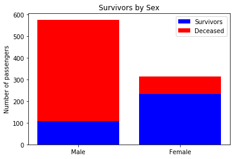

```python
gendersurvived = df[['Sex','Survived']]
fs = len(gendersurvived[(gendersurvived['Sex'] == 1) & (gendersurvived['Survived'] == 1)])
fnots = len(gendersurvived[(gendersurvived['Sex'] == 1) & (gendersurvived['Survived'] == 0)])
ms = len(gendersurvived[(gendersurvived['Sex'] == 0) & (gendersurvived['Survived'] == 1)])
mnots =len(gendersurvived[(gendersurvived['Sex'] == 0) & (gendersurvived['Survived'] == 0)])

A = [ms,fs]
B = [mnots, fnots]
X=np.arange(2)
plt.ylabel('Number of passengers')
plt.title('Survivors by Sex')
plt.xticks(X, ('Male', 'Female'))
p1= plt.bar(X, A, color = 'b')
p2=plt.bar(X, B, color = 'r', bottom = A)

plt.legend((p1[0], p2[0]), ('Survivors', 'Deceased'))

plt.show()
```